# Data Analysis of IMDb Top 100 Movies

Pratik Jadhav

2023-02-20

## Introduction

Name of the dataset: IMDb Top 100 Movies Link to the dataset: https://docs.google.com/spreadsheets/d/1y2an91gwnVeakJ6UaJtlasXn5nUl9ggyTsCc0la-kcA/edit?usp=sharing

#### Description

The top 100 movies on the well-known movie and television review website, IMDb, are all included in the “IMDb Top 100 Movies” dataset on Kaggle. The dataset contains details about the movies, such as their movie names, gross total, run time in mins, genre, as well as their IMDb ratings and the number of votes.

## Questions

There are several interesting questions that can be solved using R from the IMDb Top 100 Movies dataset. Here are a few questions:

1. What are the top 10 highest-rated movies in the dataset?
2. What are the top 10 most popular genres among the top 100 movies?
3. How many movies in the top 100 were directed by women?
4. Which decade has the most movies in the top 100?
5. What is the average budget of the movies in the top 100?
6. What is the average length of the movies in the top 100?
7. Which actor appears in the most movies in the top 100?
8. What is the correlation between a movie’s budget and its rating in the top 100?
9. How many movies in the top 100 were released before 1960?
10. What is the average rating of the top 100 movies per year?
11. What is the median rating of the top 100 movies?
12. What is the distribution of ratings in the top 100 movies?
13. What is the highest-grossing movie in the top 100?

## Discussion on Tidying and Transforming

#### Before Tidying Screenshot:

From the following table we can see that there are a total of 9 columns and 100 rows including the heading. Before tidying the dataset, the column named ‘gross_total’ had a $ sign and M in front of the value. The ‘genre’ column had more than one variable which would make the plot vague. The ‘year’ column also had a hyphen sign before the year.

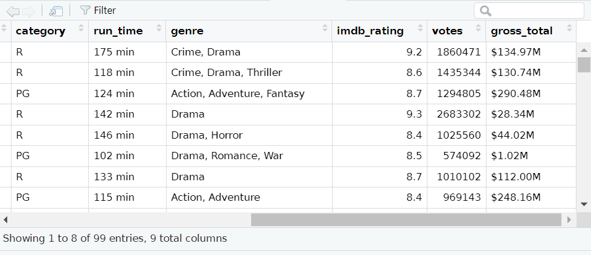

```r
knitr::include_graphics("before_tidy1.png")
```

#### After Tidying Screenshot:

From the following table, we can see that there are a total of 11 columns and 100 rows including the heading, In this table, we can see that the genre column got separated into three different columns i.e. genre_1, genre_2 and genre_3. The gross_total columns got clean i.e. the $ sign and the M was removed from the column. The hyphen sign was also removed from the year column. `

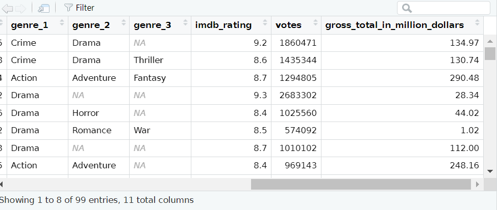

```r
knitr::include_graphics("after_tidy1.png")
```

## Data Exploration

#### Numeric Representation

```r
library(readr)
library(dplyr)
```

```r
library(tidyr)
library(ggplot2)
library(stringr)


# Load the data
library(readr)
movies <- read_csv("movies - movies.csv")
names(movies)
```

```
## [1] "index"                          "movie_name"
## [3] "year_of_release"                "category"
## [5] "run_time_in_min"                "genre"
## [7] "imdb_rating"                    "votes"
## [9] "gross_total_in_million_dollars"
```

```r
# Split the genre column into separate columns
movies_01 <- movies %>%
  separate(genre, c("genre_1", "genre_2", "genre_3"), sep = ", ")
#Numeric Summary
summary(movies)
```

```
##      index       movie_name        year_of_release   category
##  Min.   : 1.0   Length:99          Min.   :1931    Length:99
##  1st Qu.:25.5   Class :character   1st Qu.:1979    Class :character
##  Median :50.0   Mode  :character   Median :1995    Mode  :character
##  Mean   :50.0                      Mean   :1989
##  3rd Qu.:74.5                      3rd Qu.:2003
##  Max.   :99.0                      Max.   :2015
##
##  run_time_in_min    genre            imdb_rating        votes
##  Min.   : 87.0   Length:99          Min.   :7.200   Min.   :  10748
##  1st Qu.:115.5   Class :character   1st Qu.:8.100   1st Qu.: 510585
##  Median :130.0   Mode  :character   Median :8.300   Median : 834842
##  Mean   :133.6                      Mean   :8.348   Mean   : 934853
##  3rd Qu.:147.5                      3rd Qu.:8.600   3rd Qu.:1224917
##  Max.   :238.0                      Max.   :9.300   Max.   :2683302
##
##  gross_total_in_million_dollars
##  Min.   :  0.02
##  1st Qu.: 28.28
##  Median : 68.77
##  Mean   :117.43
##  3rd Qu.:160.62
##  Max.   :936.66
##  NA's   :1
```

```r
table(movies_01$movie_name)
```

[output not shown]

[output cut: 144 more lines]

```
##                                                 1
##                                         The Thing
##                                                 1
##                                     The Third Man
##                                                 1
##                                The Usual Suspects
##                                                 1
##                              To Have and Have Not
##                                                 1
##                                     Trainspotting
##                                                 1
##                                    V for Vendetta
##                                                 1
##                                           Vertigo
##                                                 1
```

```r
table(movies_01$movie_name)
```

[output not shown]

[output cut: 144 more lines]

```
##                                                 1
##                                         The Thing
##                                                 1
##                                     The Third Man
##                                                 1
##                                The Usual Suspects
##                                                 1
##                              To Have and Have Not
##                                                 1
##                                     Trainspotting
##                                                 1
##                                    V for Vendetta
##                                                 1
##                                           Vertigo
##                                                 1
```

```r
head(movies_01)
```

```
## # A tibble: 6 × 11
##   index movie_n…¹ year_…² categ…³ run_t…⁴ genre_1 genre_2 genre_3 imdb_…⁵  votes
##   <dbl> <chr>       <dbl> <chr>     <dbl> <chr>   <chr>   <chr>     <dbl>  <dbl>
## 1     1 The Godf…    1972 R           175 Crime   Drama   <NA>        9.2 1.86e6
## 2     2 The Sile…    1991 R           118 Crime   Drama   Thrill…     8.6 1.44e6
## 3     3 Star War…    1980 PG          124 Action  Advent… Fantasy     8.7 1.29e6
## 4     4 The Shaw…    1994 R           142 Drama   <NA>    <NA>        9.3 2.68e6
## 5     5 The Shin…    1980 R           146 Drama   Horror  <NA>        8.4 1.03e6
## 6     6 Casablan…    1942 PG          102 Drama   Romance War         8.5 5.74e5
## # … with 1 more variable: gross_total_in_million_dollars <dbl>, and abbreviated
## #   variable names ¹movie_name, ²year_of_release, ³category, ⁴run_time_in_min,
## #   ⁵imdb_rating
```

```r
tail(movies_01)
```

```
## # A tibble: 6 × 11
##   index movie_n…¹ year_…² categ…³ run_t…⁴ genre_1 genre_2 genre_3 imdb_…⁵  votes
##   <dbl> <chr>       <dbl> <chr>     <dbl> <chr>   <chr>   <chr>     <dbl>  <dbl>
## 1    94 Heat         1995 R           170 Action  Crime   Drama       8.3 6.58e5
## 2    95 The Usua…    1995 R           106 Crime   Drama   Mystery     8.5 1.09e6
## 3    96 Cool Han…    1967 GP          127 Crime   Drama   <NA>        8.1 1.79e5
## 4    97 Eternal …    2004 R           108 Drama   Romance Sci-Fi      8.3 1.01e6
## 5    98 City Lig…    1931 G            87 Comedy  Drama   Romance     8.5 1.86e5
## 6    99 The Matr…    1999 R           136 Action  Sci-Fi  <NA>        8.7 1.92e6
## # … with 1 more variable: gross_total_in_million_dollars <dbl>, and abbreviated
## #   variable names ¹movie_name, ²year_of_release, ³category, ⁴run_time_in_min,
## #   ⁵imdb_rating
```

```r
str(movies_01)
```

```
## tibble [99 × 11] (S3: tbl_df/tbl/data.frame)
##  $ index                         : num [1:99] 1 2 3 4 5 6 7 8 9 10 ...
##  $ movie_name                    : chr [1:99] "The Godfather" "The Silence of the Lambs" "Star Wars: Episode V - The Empire Strikes Back" "The Shawshank Redemption" ...
##  $ year_of_release               : num [1:99] 1972 1991 1980 1994 1980 ...
##  $ category                      : chr [1:99] "R" "R" "PG" "R" ...
##  $ run_time_in_min               : num [1:99] 175 118 124 142 146 102 133 115 201 121 ...
##  $ genre_1                       : chr [1:99] "Crime" "Crime" "Action" "Drama" ...
##  $ genre_2                       : chr [1:99] "Drama" "Drama" "Adventure" NA ...
##  $ genre_3                       : chr [1:99] NA "Thriller" "Fantasy" NA ...
##  $ imdb_rating                   : num [1:99] 9.2 8.6 8.7 9.3 8.4 8.5 8.7 8.4 9 8.6 ...
##  $ votes                         : num [1:99] 1860471 1435344 1294805 2683302 1025560 ...
##  $ gross_total_in_million_dollars: num [1:99] 135 130.7 290.5 28.3 44 ...
```

```r
median(movies_01$imdb_rating)
```

```
## [1] 8.3
```

```r
mean(movies_01$imdb_rating)
```

```
## [1] 8.348485
```

```r
min(movies_01$imdb_rating)
```

```
## [1] 7.2
```

```r
range(movies_01$imdb_rating)
```

```
## [1] 7.2 9.3
```

```r
var(movies_01$imdb_rating)
```

```
## [1] 0.1359926
```

```r
quantile(movies_01$imdb_rating,0.5)
```

```
## 50%
## 8.3
```

```r
quantile(movies_01$imdb_rating,0.25)
```

```
## 25%
## 8.1
```

```r
quantile(movies_01$imdb_rating,0.75)
```

```
## 75%
## 8.6
```

```r
quantile(movies_01$imdb_rating,0.5)
```

```
## 50%
## 8.3
```

```r
quantile(movies_01$imdb_rating,0.25)
```

```
## 25%
## 8.1
```

```r
quantile(movies_01$imdb_rating,0.75)
```

```
## 75%
## 8.6
```

```r
IQR(movies_01$imdb_rating)
```

```
## [1] 0.5
```

```r
1:20
```

```
##  [1]  1  2  3  4  5  6  7  8  9 10 11 12 13 14 15 16 17 18 19 20
```

```r
seq(1,20,2)
```

```
##  [1]  1  3  5  7  9 11 13 15 17 19
```

```r
quantile(movies_01$imdb_rating,0.25)
```

```
## 25%
## 8.1
```

```r
seq(0,1,0.25)
```

```
## [1] 0.00 0.25 0.50 0.75 1.00
```

```r
quantile(movies_01$imdb_rating, seq(0,1,0.25))
```

```
##   0%  25%  50%  75% 100%
##  7.2  8.1  8.3  8.6  9.3
```

```r
quantile(movies_01$imdb_rating, seq(0,1,0.05))
```

```
##   0%   5%  10%  15%  20%  25%  30%  35%  40%  45%  50%  55%  60%  65%  70%  75%
## 7.20 7.79 7.90 8.00 8.10 8.10 8.20 8.20 8.30 8.30 8.30 8.40 8.40 8.50 8.50 8.60
##  80%  85%  90%  95% 100%
## 8.60 8.70 8.80 9.00 9.30
```

```r
quantile(movies_01$imdb_rating, seq(0,1,0.25),1)
```

```
##   0%  25%  50%  75% 100%
##  7.2  8.1  8.3  8.6  9.3
```

```r
round(quantile(movies_01$imdb_rating, seq(0,1,0.25)),1)
```

```
##   0%  25%  50%  75% 100%
##  7.2  8.1  8.3  8.6  9.3
```

```r
round(quantile(movies_01$imdb_rating, seq(0,1,0.05)),1)
```

```
##   0%   5%  10%  15%  20%  25%  30%  35%  40%  45%  50%  55%  60%  65%  70%  75%
##  7.2  7.8  7.9  8.0  8.1  8.1  8.2  8.2  8.3  8.3  8.3  8.4  8.4  8.5  8.5  8.6
##  80%  85%  90%  95% 100%
##  8.6  8.7  8.8  9.0  9.3
```

#### Visual Representation:

##### Data Visualization using one Variable

```r
table(movies_01$category)
```

```
##
## Approved        G       GP   Passed       PG    PG-13        R
##        4        6        1        3       11       16       58
```

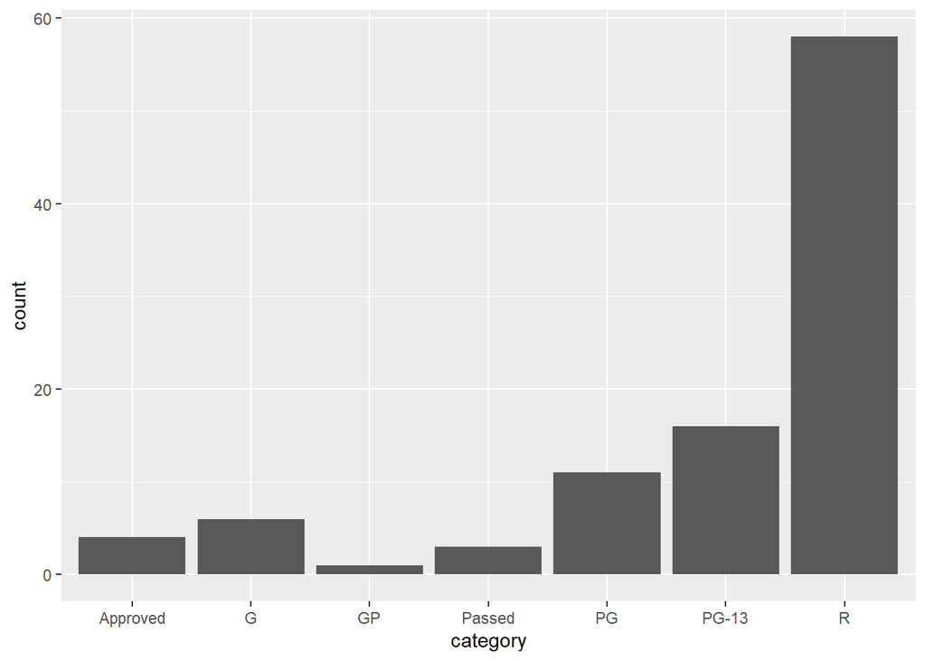

```r
g1 <- ggplot(data = movies_01)

g1 + geom_bar(aes(category))
```

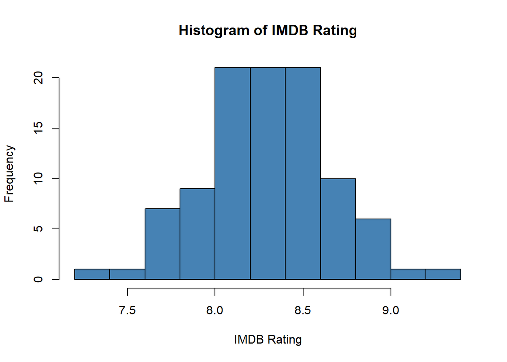

```r
#Histogram of imdb rating

hist(movies$imdb_rating,
     breaks = 15,
     main = "Histogram of IMDB Rating",
     xlab = "IMDB Rating",
     col = "steelblue")
```

From the aforementioned plot, we can conclude that most of the IMDb ratings from the IMDb list of the top 100 movies lie between 8-8.5. The frequency of the movies is around 20 for the IMDb rating is between 8 to 8.5.

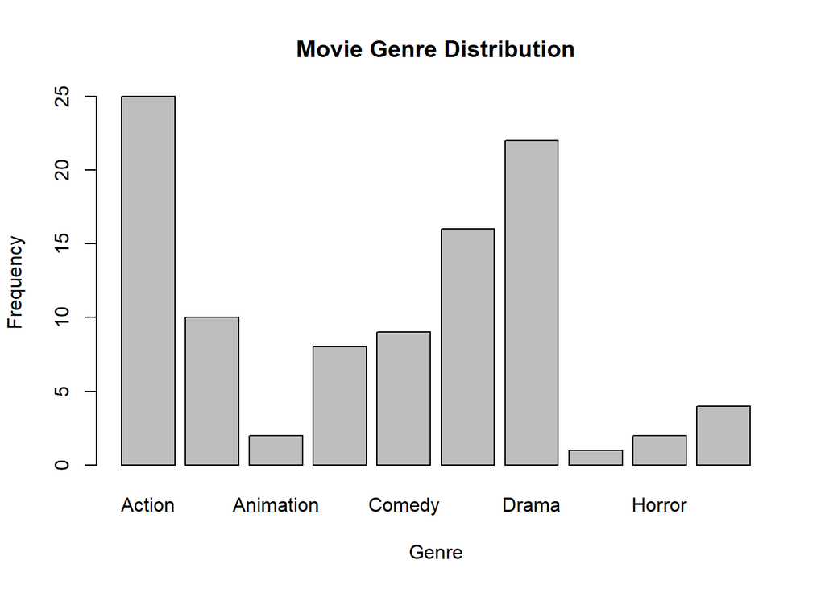

```r
#bar plot of genre

barplot_movies <- table(movies_01$genre_1)
barplot(barplot_movies, main = "Movie Genre Distribution",
        xlab = "Genre", ylab = "Frequency")
```

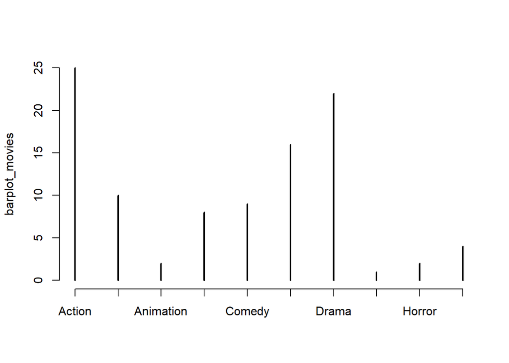

```r
plot(barplot_movies)
```

From the plot mentioned above, we can see that the genre distribution over movies is uneven. In the IMDb list of top 100 movies the genre with the highest frequency is ‘Action’ and the genre with the lowest frequency is ‘Film-Noir’. We may also infer that the genres most popular with the audience followed by ‘Action’ are ‘Drama’ and ‘Crime.’

##### Data Visualization using two variables

[figure not shown]

```r
#Duration Vs. Year
g1<-ggplot(data= movies_01,
           aes(x=year_of_release,y = run_time_in_min))
g1
```

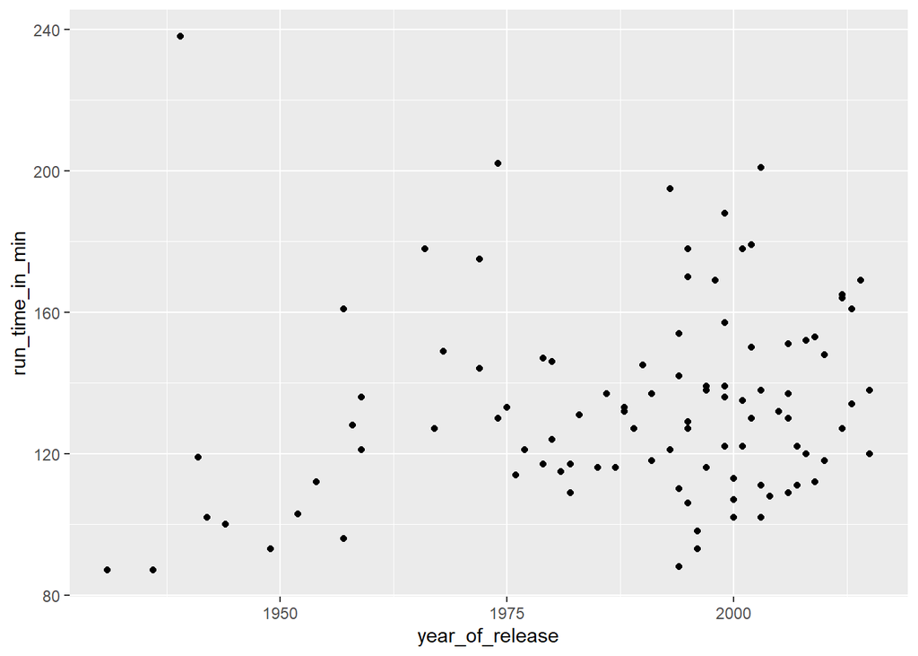

```r
g1+geom_point()
```

[figure not shown]

```r
g1+geom_point(alpha= 0)
```

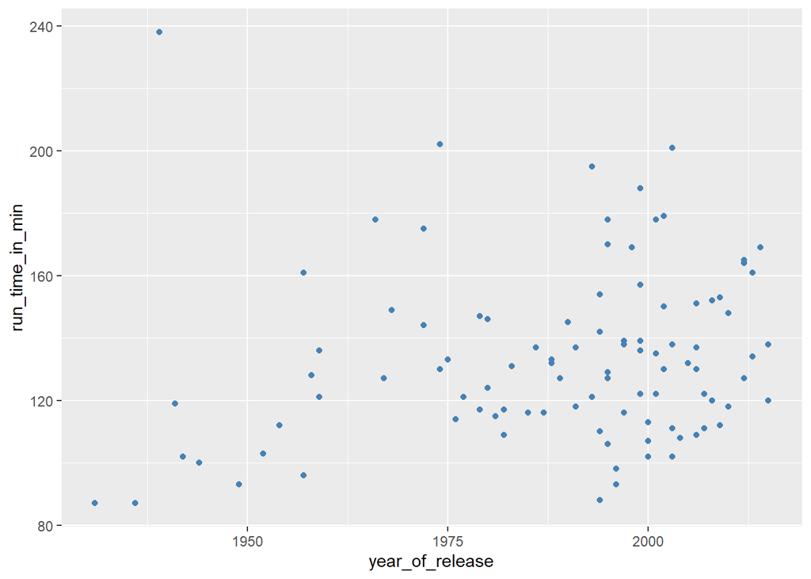

```r
g1+geom_point(alpha= 1, color = 'steelblue')
```

From the aforementioned plot, we can see that before 1950 there were few movies from the IMDb list of the top 100 movies which were of duration from 80-120 mins and one movie of a duration of around 240 mins.

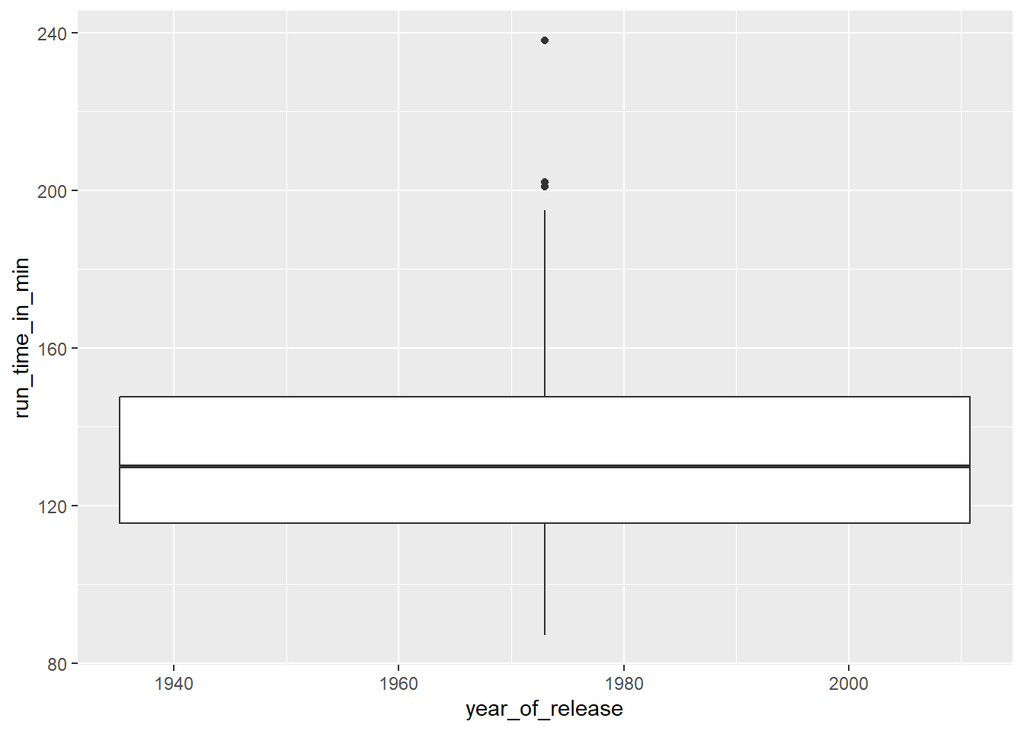

```r
g1+geom_boxplot(alpha= 1)
```

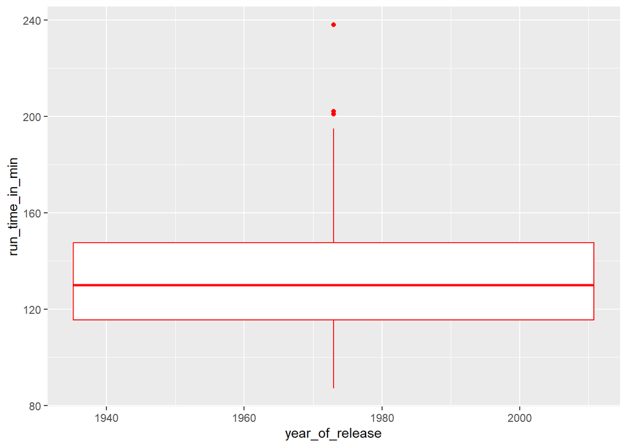

```r
g1+geom_boxplot(alpha= 1, color = 'red')
```

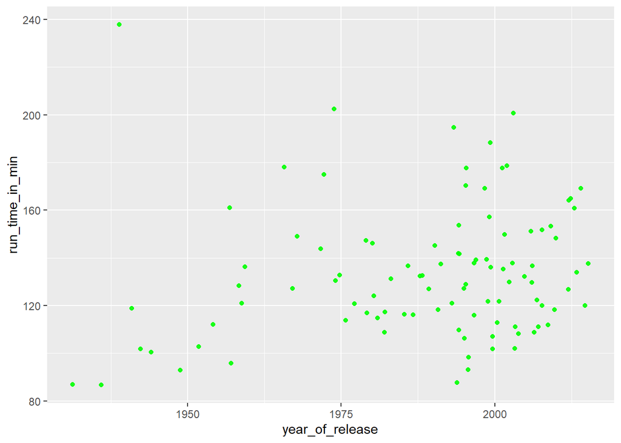

```r
g1+geom_jitter(alpha = 0.9, color = "green")
```

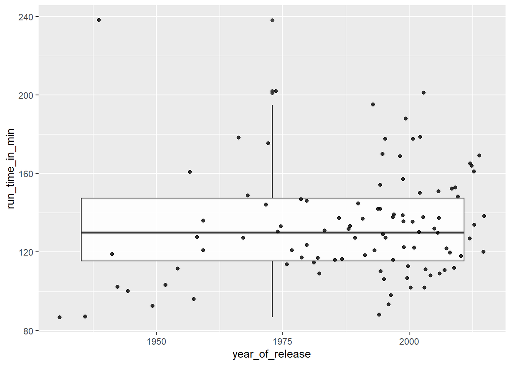

```r
g1+geom_boxplot(alpha = 0.9)+geom_jitter(alpha = 0.8)
```

[figure not shown]

```r
#genre vs imdb rating
g2<-ggplot(data= movies_01,
           aes(x= genre_1,y = imdb_rating))
g2
```

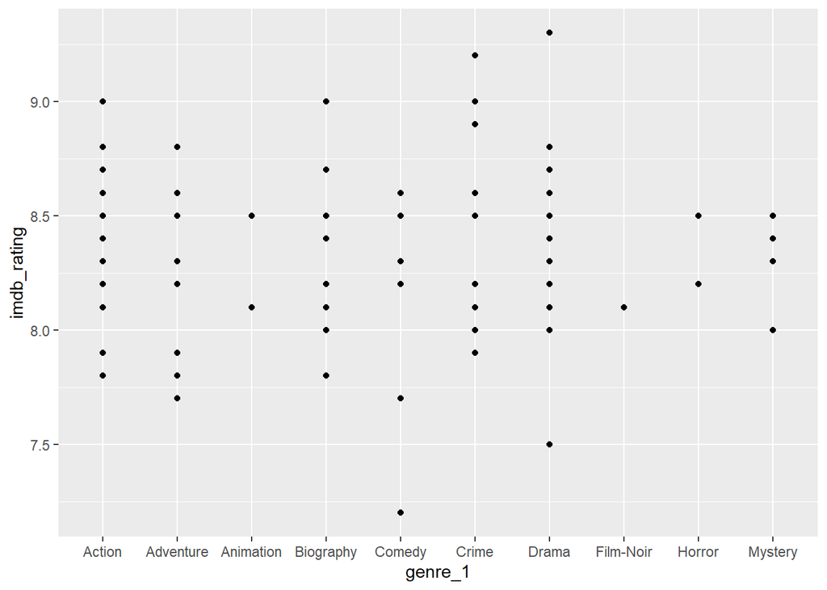

```r
g2+geom_point()
```

[figure not shown]

```r
g2+geom_point(alpha= 0)
```